# final exam

group 16

2025/05/26

### Part 1:實作題（30分，每題10分）

```r
FF_joined <- st_join(food, vill["TOWN"])
TPV_A = dplyr::filter(FF_joined, TOWN %in% c("文山區", "大安區", "中正區"))
TPV_B = dplyr::filter(FF_joined, TOWN %in% c("信義區", "南港區", "松山區"))
buffer_A <- st_buffer(TPV_A, dist = 1000)
buffer_B <- st_buffer(TPV_B, dist = 1000)

count_schools <- function(buffers, schools) {
  sapply(1:nrow(buffers), function(i) {
    sum(st_intersects(buffers[i, ], schools, sparse = FALSE))
  })
}

schools_in_A <- count_schools(buffer_A, school)
schools_in_B <- count_schools(buffer_B, school)

buffer_A$school_count <- schools_in_A
buffer_B$school_count <- schools_in_B
t_test_result <- t.test(schools_in_A, schools_in_B, var.equal = FALSE)
t_test_result
```

```
    Welch Two Sample t-test

data:  schools_in_A and schools_in_B
t = 1.5977, df = 51, p-value = 0.1163
alternative hypothesis: true difference in means is not equal to 0
95 percent confidence interval:
 -0.1418044  1.2473762
sample estimates:
mean of x mean of y
 3.870968  3.318182
```

#### 2. 以 500 公尺方格的空間單位建立網格，依照 contiguity 鄰近定義，計算並繪製速食店總數的 Moran’s correlogram，解讀其圖表資訊，並評估速食店的空間影響範圍。

[figure not shown]

```r
taipei_boundary <- st_union(vill)

grid_500 <- st_make_grid(taipei_boundary, cellsize = 500, square = TRUE) %>% st_sf() %>%
  st_intersection(taipei_boundary)
grid_500$fastfood_count <- lengths(st_intersects(grid_500, food))

grid_sp <- as(grid_500, "Spatial")

nb <- poly2nb(grid_sp, queen = TRUE)

lw <- nb2listw(nb, style = "W")
grid_500$jittered_count <- jitter(grid_500$fastfood_count, amount = 0.1)
moran_corr <- sp.correlogram(nb, grid_500$jittered_count, order = 10, method = "I", style = "W", zero.policy = TRUE)

moran_df <- data.frame(
  order = 1:length(moran_corr$res),
  moran_I = sapply(moran_corr$res, function(x) x[1])
)
ggplot(moran_df, aes(x = order, y = moran_I)) +
  geom_line(color = "blue", size = 1) +
  geom_point(size = 3) +
  geom_hline(yintercept = 0, linetype = "dashed", color = "gray") +
  labs(
    title = "Moran's I Correlogram for Fast Food Count (500m Grid)",
    x = "Order of Contiguity",
    y = "Moran's I"
  ) +
  scale_y_continuous(breaks = seq(-0.001, 0.2, by = 0.01)) +
  theme_minimal()
```

#### 在order ≦ 10，moran’s I皆大於0。因此，在大約5公里(500m*10)之前的範圍內，速食店呈現群聚分布，具空間自相關現象，而隨著距離越來越遠，moran’s I 趨近於0，速食店呈現隨機分布，無空間自相關現象。

#### 3. 依照前一小題的網格為空間單位，依照 contiguity 鄰近定義，計算 Gi*統計量，分別繪製速食店家數與學校在 0.05 顯著水準的熱區分佈（需進行多重檢定的修正）。

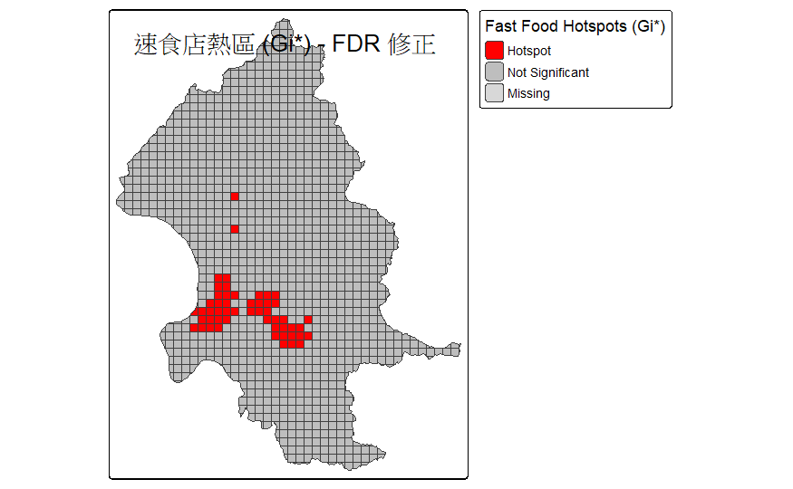

```r
grid_500m <- st_make_grid(taipei_boundary, cellsize = 500, square = TRUE) %>% st_sf() %>%
  st_intersection(taipei_boundary)
grid_500m$grid_id <- 1:nrow(grid_500m)

fastfood_join <- st_join(food, grid_500m, left = FALSE)
fastfood_count <- fastfood_join %>%
  group_by(grid_id) %>%
  summarise(fastfood_n = n())

school_join <- st_join(school, grid_500m, left = FALSE)
school_count <- school_join %>%
  group_by(grid_id) %>%
  summarise(school_n = n())

grid_500m <- st_join(grid_500m, fastfood_count, by = "grid_id")
grid_500m <- st_join(grid_500m, school_count, by = "grid_id")
grid_500m$fastfood_n[is.na(grid_500m$fastfood_n)] <- 0
grid_500m$school_n[is.na(grid_500m$school_n)] <- 0
nb <- poly2nb(grid_500m, queen = TRUE)
lw <- nb2listw(nb, style = "W")
gi_fast <- localG(grid_500m$fastfood_n, lw)
gi_school <- localG(grid_500m$school_n, lw)

grid_500m$gi_fast <- as.numeric(gi_fast)
grid_500m$gi_school <- as.numeric(gi_school)

grid_500m$p_fast <- 2 * pnorm(-abs(grid_500m$gi_fast))
grid_500m$p_fast_adj <- p.adjust(grid_500m$p_fast, method = "fdr")
grid_500m$hotspot_fast <- ifelse(grid_500m$p_fast_adj < 0.05 & grid_500m$gi_fast > 0, "Hotspot",
                           ifelse(grid_500m$p_fast_adj < 0.05 & grid_500m$gi_fast < 0, "Coldspot", "Not Significant"))

grid_500m$p_school <- 2 * pnorm(-abs(grid_500m$gi_school))
grid_500m$p_school_adj <- p.adjust(grid_500m$p_school, method = "fdr")
grid_500m$hotspot_school <- ifelse(grid_500m$p_school_adj < 0.05 & grid_500m$gi_school > 0, "Hotspot",
                             ifelse(grid_500m$p_school_adj < 0.05 & grid_500m$gi_school < 0, "Coldspot", "Not Significant"))
tmap_mode("plot")

tm_shape(grid_500m) +
  tm_polygons(
    col = "hotspot_fast",
    palette = c("red", "grey"),
    legend.show = TRUE,
    title = "Fast Food Hotspots (Gi*)"
  ) +
  tm_borders() +
  tm_layout(title = "速食店熱區 (Gi*) - FDR 修正", legend.outside = TRUE)
```

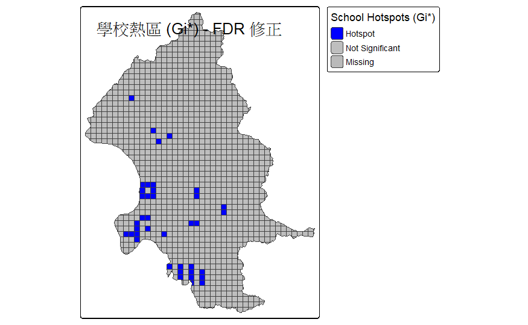

```r
tm_shape(grid_500m) +
  tm_polygons(
    col = "hotspot_school",
    palette = c("blue", "grey"),
    legend.show = TRUE,
    title = "School Hotspots (Gi*)"
  ) +
  tm_borders() +
  tm_layout(title = "學校熱區 (Gi*) - FDR 修正", legend.outside = TRUE)
```

### Part 2：學校附近的速食店數量真的比較多嗎?

#### 1. 請參考Transportation Research Part A, 45 (2011) 640–652（HW-09 的研讀教材）所使 用F(d)函數的作法，比較分別位於大安區、文山區與信義區的學校，到鄰近速食店的空間特徵。

```r
target_vill <- vill %>% filter(TOWN %in% c("大安區", "文山區", "信義區"))
school_sel <- st_join(school, target_vill, join = st_within) %>% filter(!is.na(TOWN))
food_sel <- st_join(food, target_vill, join = st_within) %>% filter(!is.na(TOWN))

sf_to_ppp <- function(points_sf, window_polygon) {
  win <- as.owin(st_union(window_polygon))

  coords <- st_coordinates(points_sf)

  ppp_obj <- ppp(x = coords[,1], y = coords[,2], window = win)
  return(ppp_obj)
}

districts <- c("大安區", "文山區", "信義區")

fd_results <- list()

for (dist in districts) {
  dist_vill <- target_vill %>% filter(TOWN == dist)
  dist_school <- school_sel %>% filter(TOWN == dist)
  dist_food <- food_sel %>% filter(TOWN == dist)

  food_ppp <- sf_to_ppp(dist_food, dist_vill)

  school_coords <- st_coordinates(dist_school)
  marks <- rep(1, nrow(school_coords))
  school_ppp <- ppp(school_coords[,1], school_coords[,2], window = food_ppp$window, marks = marks)

  fd <- Fest(food_ppp, correction = "border")

  fd_results[[dist]] <- fd
}

plot(fd_results[["大安區"]], main = "F(d) function(大安,信義,文山)", col = "red")
plot(fd_results[["文山區"]], add = TRUE, col = "blue")
```

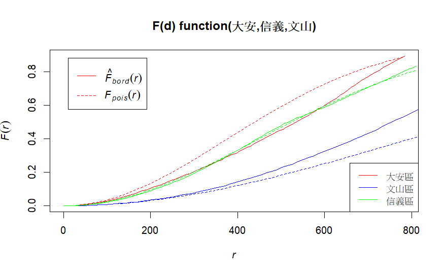

```r
plot(fd_results[["信義區"]], add = TRUE, col = "green")
legend("bottomright", legend = districts, col = c("red", "blue", "green"), lty = 1)
```

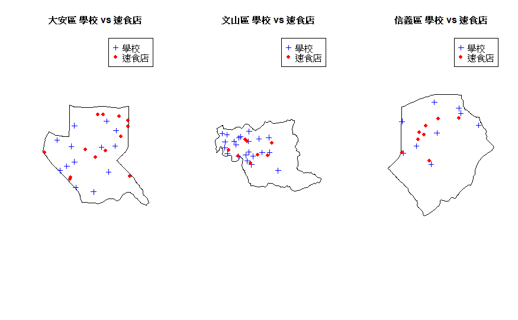

```r
par(mfrow = c(1, 3))  # 三區並排
for (dist in districts) {
  dist_vill <- target_vill %>% filter(TOWN == dist)
  dist_school <- school_sel %>% filter(TOWN == dist)
  dist_food <- food_sel %>% filter(TOWN == dist)

  win <- as.owin(st_union(dist_vill))
  school_coords <- st_coordinates(dist_school)
  food_coords <- st_coordinates(dist_food)

  school_ppp <- ppp(school_coords[,1], school_coords[,2], window = win)
  food_ppp   <- ppp(food_coords[,1], food_coords[,2], window = win)

  plot(school_ppp, main = paste(dist, "學校 vs 速食店"), cols = "blue", pch = 3)
  points(food_ppp, col = "red", pch = 16)
  legend("topright", legend = c("學校", "速食店"), col = c("blue", "red"), pch = c(3, 16))
}
```

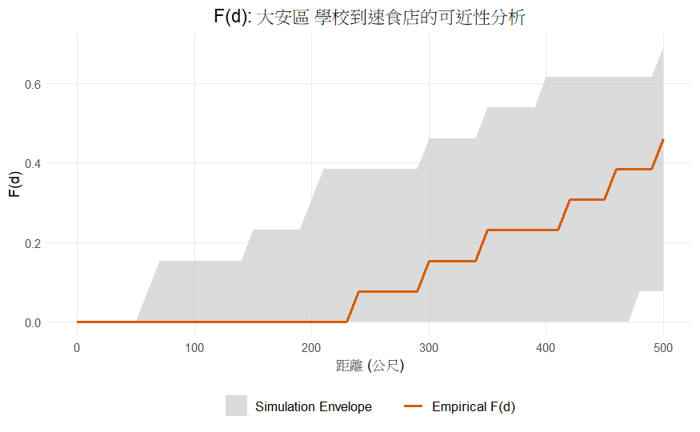

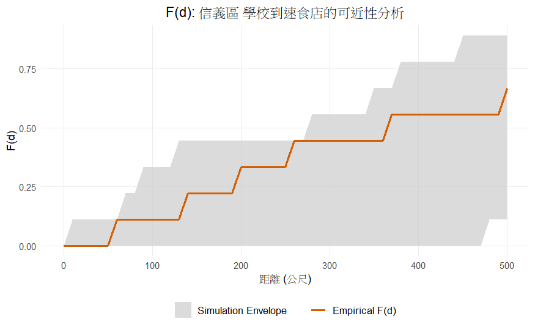

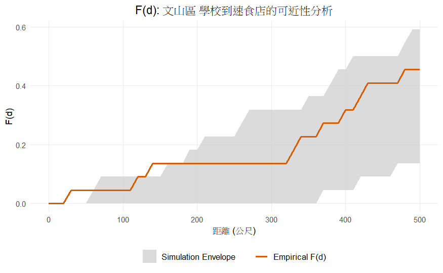

```r
districts <- c("大安區", "信義區", "文山區")

for (dist in districts) {

  dist_school <- school_sel %>% filter(TOWN == dist)
  dist_food   <- food_sel   %>% filter(TOWN == dist)

  distances <- st_distance(dist_school, dist_food) %>%
    apply(1, min) %>%
    as.numeric()

  d_values <- seq(0, 500, by = 10)
  F_empirical <- sapply(d_values, function(d) mean(distances <= d))

  n_random_points <- 500
  n_samples <- nrow(dist_school)
  n_sim <- 99

  bbox <- st_bbox(dist_school)
  random_points <- st_as_sf(
    data.frame(
      x = runif(n_random_points, bbox["xmin"], bbox["xmax"]),
      y = runif(n_random_points, bbox["ymin"], bbox["ymax"])
    ),
    coords = c("x", "y"),
    crs = st_crs(dist_school)
  )

  dist_food_proj <- st_transform(dist_food, 32618)
  random_points_proj <- st_transform(random_points, 32618)

  sim_results <- matrix(nrow = length(d_values), ncol = n_sim)

  for (i in 1:n_sim) {
    sampled_points <- random_points_proj %>%
      sample_n(n_samples)

    sim_distances <- st_distance(sampled_points, dist_food_proj) %>%
      apply(1, min) %>%
      as.numeric()

    sim_results[, i] <- sapply(d_values, function(d) mean(sim_distances <= d))
  }

  envelope_lower <- apply(sim_results, 1, min)
  envelope_upper <- apply(sim_results, 1, max)

  plot_data <- data.frame(
    d = d_values,
    Empirical = F_empirical,
    Lower = envelope_lower,
    Upper = envelope_upper
  )

  p <- ggplot(plot_data, aes(x = d)) +
    geom_ribbon(aes(ymin = Lower, ymax = Upper, fill = "Simulation Envelope"),
                alpha = 0.7) +
    geom_line(aes(y = Empirical, color = "Empirical F(d)"), linewidth = 1) +
    scale_fill_manual(name = NULL, values = c("Simulation Envelope" = "grey80")) +
    scale_color_manual(name = NULL, values = c("Empirical F(d)" = "#D55E00")) +
    labs(
      x = "距離 (公尺)",
      y = "F(d)",
      title = paste0("F(d): ", dist, " 學校到速食店的可近性分析")
    ) +
    theme_minimal() +
    theme(
      panel.grid.minor = element_blank(),
      plot.title = element_text(hjust = 0.5, size = 14),
      legend.position = "bottom",
      legend.text = element_text(size = 10)
    )

  print(p)
}
```

#### 雖然從confidence envelope來看，三區皆呈現隨機分布，但從f-function的曲線可以看到大安區學校與速食店較偏向cluster分布,信義區學校與速食店較偏向random分布,文山區學校與速食店較偏向dispersion分布，顯現出大安區附近有較多速食店，反映三區在學校與速食店實際距離關係上的結構性差異，這些差異可能來自地理面積、建成環境密度等因素

#### 2. 利用 Ripley’s K function, k(d)計算速食店在 distance (d) = 3000 公尺時的 K(3000) 以及 L(3000)，並使用 Monte Carlo significance test 計算 L(3000)的 95%信賴區間

```r
food_proj <- st_transform(food, 3826)
vill_proj <- st_transform(vill, 3826)

taipei_win <- as.owin(st_union(vill_proj))
coords <- st_coordinates(food_proj)
food_ppp <- ppp(x = coords[,1], y = coords[,2], window = taipei_win)

K_result <- Kest(food_ppp, correction = "border")
K3000 <- K_result$border[which.min(abs(K_result$r - 3000))]
L3000 <- sqrt(K3000 / pi) - 3000

cat("K(3000) =", K3000, "\n")
```

```
K(3000) = 67640147
```

```r
cat("L(3000) =", L3000, "\n")
```

```
L(3000) = 1640.1
```

```r
taipei_win <- as.owin(st_union(vill))

set.seed(123)
env <- envelope(
  food_ppp,
  fun = Kest,
  nsim = 99,
  nrank = 5,
  correction = "border",
  savefuns = TRUE
)
```

```
Generating 99 simulations of CSR  ...
1, 2, 3, 4, 5, 6, 7, 8, 9, 10, 11, 12, 13, 14, 15, 16, 17, 18, 19, 20, 21, 22, 23, 24, 25, 26,
27, 28, 29, 30, 31, 32, 33, 34, 35, 36, 37, 38, 39, 40, 41, 42, 43, 44, 45, 46, 47, 48, 49, 50, 51, 52,
53, 54, 55, 56, 57, 58, 59, 60, 61, 62, 63, 64, 65, 66, 67, 68, 69, 70, 71, 72, 73, 74, 75, 76, 77, 78,
79, 80, 81, 82, 83, 84, 85, 86, 87, 88, 89, 90, 91, 92, 93, 94, 95, 96, 97, 98,
99.

Done.
```

```r
env_L <- eval.fv(sqrt(env / pi)-3000)

L3000_lo <- env_L$lo[which.min(abs(env_L$r - 3000))]
L3000_hi <- env_L$hi[which.min(abs(env_L$r - 3000))]

cat("L(3000) 95% 信賴區間：", L3000_lo, "~", L3000_hi, "\n")
```

```
L(3000) 95% 信賴區間： -306.9529 ~ 282.8214
```

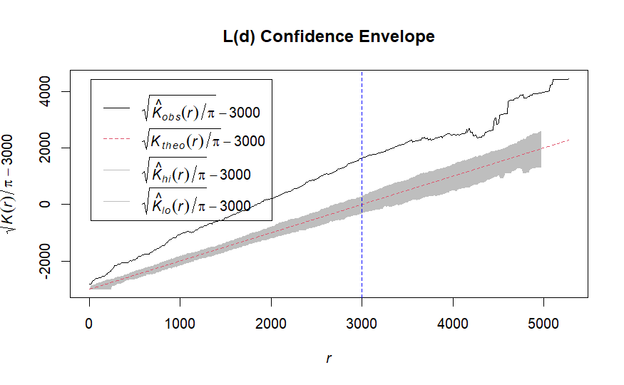

```r
plot(env_L, main = "L(d) Confidence Envelope")
abline(v = 3000, col = "blue", lty = 2)
```

#### 從R-consule的計算結果可以看到L(3000)=1640.1遠大於信賴區間上限282.821，因此顯示距離3000公尺的尺度下，台北速食店分布呈現顯著「cluster」分布

#### 從ci圖可以看到黑線(觀測值)整體高於envelope，印證了在3000公尺尺度下，台北速食店分布顯示顯著的cluster分布

#### 3. 利用Bivariate F function分析方法，比較公立vs.私立學校，到鄰近速食店的空間特徵，並說明哪一種類型學校的附近，會有較多的速食店？（顯著水準=0.05）

```r
pub = school[school$Type == "公立", ]
pri = school[school$Type == "私立", ]

coord_pub = st_coordinates(pub)
coord_pri = st_coordinates(pri)
coord_ff = st_coordinates(food)

windows = as.owin(st_union(vill))

pub_pp = as.ppp(coord_pub, windows)
pri_pp = as.ppp(coord_pri, windows)
ff_pp = as.ppp(coord_ff, windows)

NND_pub = nncross(pub_pp, ff_pp)
Fd_pub = ecdf(NND_pub$dist)

NND_pri = nncross(pri_pp, ff_pp)
Fd_pri = ecdf(NND_pri$dist)

n_pub = pub_pp$n
n_pri = pri_pp$n

F_sim_pub = matrix(nrow=99, ncol=n_pub)
for(i in 1:99){
  RND = rpoint(n_pub, win = windows)
  F_sim_pub[i, ] = nncross(RND, ff_pp)$dist
}
F_sim_s_pub = t(apply(F_sim_pub,1,sort))
F_sim_sort_pub = apply(F_sim_s_pub, 2, sort)

F_sim_pri = matrix(nrow=99, ncol=n_pri)
for(i in 1:99){
  RND = rpoint(n_pri, win = windows)
  F_sim_pri[i, ] = nncross(RND, ff_pp)$dist
}
F_sim_s_pri = t(apply(F_sim_pri,1,sort))
F_sim_sort_pri = apply(F_sim_s_pri, 2, sort)

plot(Fd_pub, col="blue", cex=0, main="F function: 公立學校 → 速食店", xlab="距離", ylab="F(d)", xlim=c(0,4000))
for(i in 1:99){
  lines(ecdf(F_sim_pub[i,]), col="grey", verticals=T, cex=0)
}
```

```r
lines(ecdf(F_sim_sort_pub[5,]), col="black", lty=2, lwd=1.5)
lines(ecdf(F_sim_sort_pub[95,]), col="black", lty=2, lwd=1.5)
```

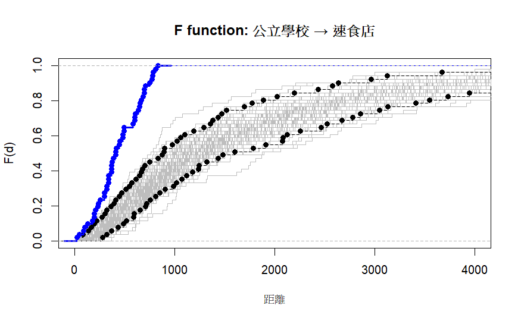

```r
lines(Fd_pub, col="blue", lwd=3)
```

```r
plot(Fd_pri, col="blue", cex=0, main="F function: 私立學校 → 速食店", xlab="距離", ylab="F(d)", xlim=c(0,4000))
for(i in 1:99){
  lines(ecdf(F_sim_pri[i,]), col="grey", verticals=T, cex=0)
}
```

```r
lines(ecdf(F_sim_sort_pri[5,]), col="black", lty=2, lwd=1.5)
lines(ecdf(F_sim_sort_pri[95,]), col="black", lty=2, lwd=1.5)
```

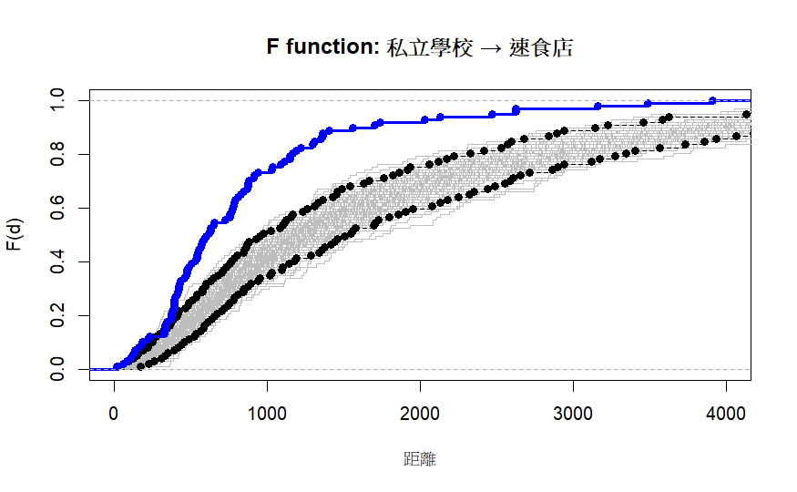

```r
lines(Fd_pri, col="blue", lwd=3)
```

```r
plot(Fd_pub, col="blue", main="公立 vs. 私立學校 → 速食店", xlab="距離", ylab="F(d)", xlim=c(0,4000))
lines(Fd_pub, col="blue", lwd=3)
```

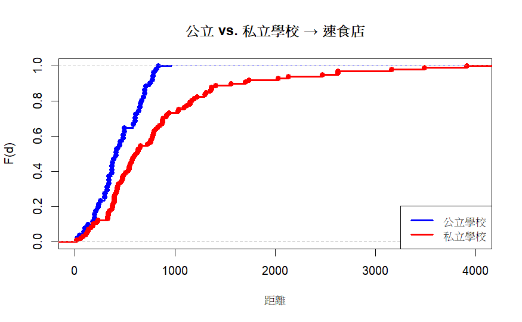

```r
lines(Fd_pri, col="red", lwd=3)
legend("bottomright", legend = c("公立學校", "私立學校"), col = c("blue", "red"), lwd = 3)
```

#### 從前兩張圖可以看到，在顯著水準0.05的情況下，台北市公私立學校附近的速食店皆呈現cluster分布，也就是兩種類型學校附近皆圍繞著速食店，而從第三張圖可以看到公立學校f-function的上升速度較快(較cluster)，換句話說，也就是公立學校附近的速食店較多